# Práctica 2. AED

Introducción a la Ciencia de Datos. Máster en Ciencia de Datos- UV

Javier Rodríguez Jiménez

2026-10-26

Cargamos, en primer lugar, la librería

```r
library(ggplot2)
```

# 1 Ejercicio 1

**a)** Carga el fichero weatherAUS.RData utilizando lo aprendido en la práctica 1.

```r
weather_aus <- load('data/weatherAUS.RData')
```

**b)** Crea un objeto ggplot denominado grafico1 en el que esté definido el conjunto de datos ds alojado en el fichero weatherAUS.RData y un aesthetics en el que en el eje $x$ esté definida la variable MinTemp y en el eje $y$ esté definida la variable MaxTemp.

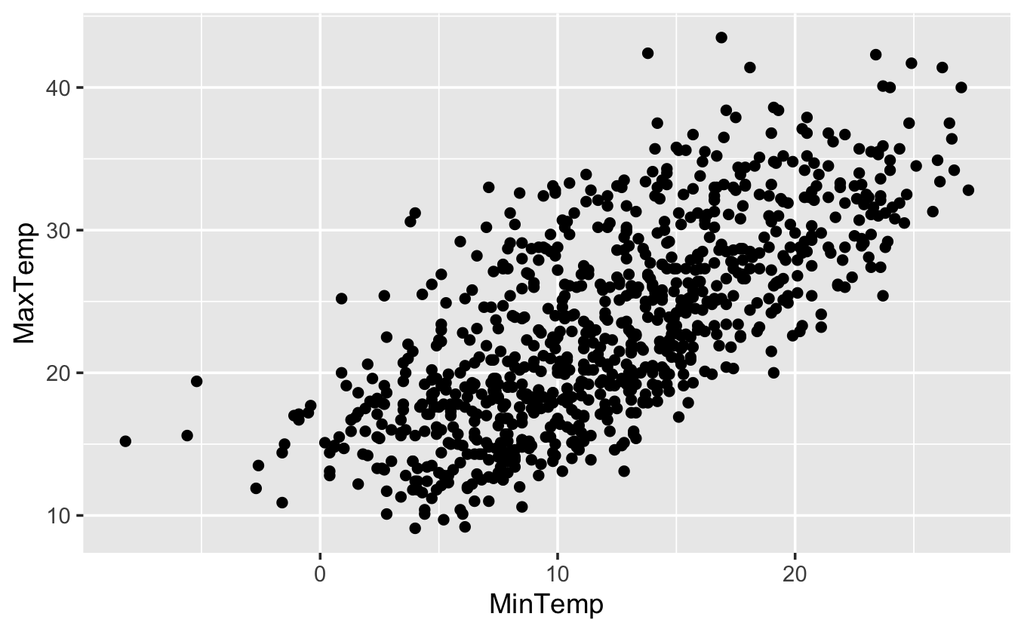

```r
grafico1 <- ggplot(ds, aes(x = MinTemp, y = MaxTemp))
grafico1+geom_point()
```

**c)** Añade una capa que defina el objeto geométrico necesario para construir un gráfico de dispersión de las variables MinTemp y MaxTemp.

```r
grafico1+geom_point()
```

**d)** Genera ahora el mismo gráfico y almacénalo en grafico2 pero define el aesthetics para visualizar las variables MinTemp y MaxTemp en los ejes de la gráfica y la variable categórica RainTomorrow como el color. A partir del objeto grafico2, representa un gráfico de dispersión en el que se muestren los puntos con el color del punto correspondiente a la variable RainTomorrow.

```r
grafico2 <- ggplot(ds, aes(x = MinTemp, y = MaxTemp, colour = RainTomorrow))
grafico2 <-grafico2 + geom_point()
```

**e)** Añade a grafico2 una capa para incluir un título con ggtitle() y almacénalo en grafico3.

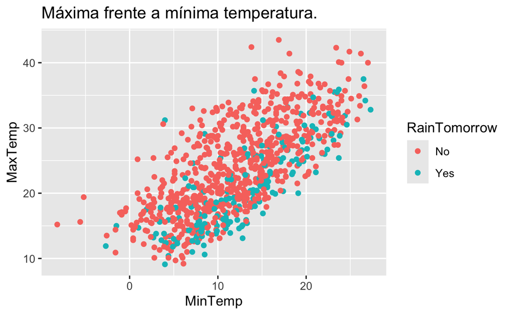

```r
grafico3 <- grafico2+ggtitle('Máxima frente a mínima temperatura.')
grafico3
```

**f)** Almacena en formato pdf el gráfico resultante en un fichero denominado Ejercicio1.pdf

```r
ggsave('results/Ejercicio1.pdf', grafico3)
```

# 2 Ejercicio 2

**a)** Utilizando ggplot haz un grafico de dispersión en el que representes las variables Temp9am y Pressure9am en los ejes $x$ e $y$, respectivamente.

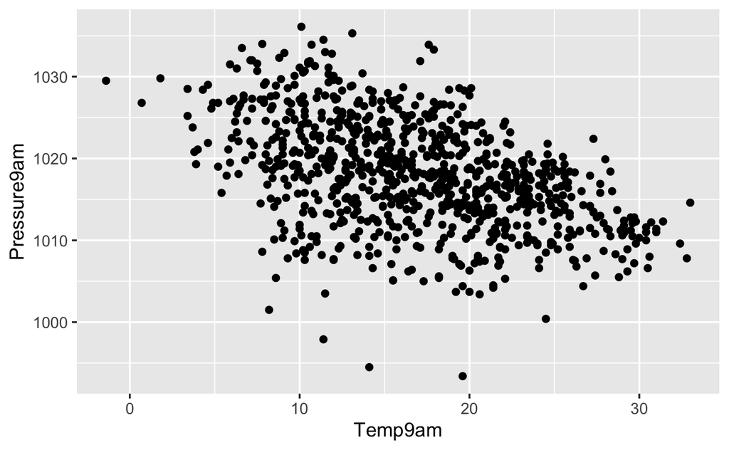

```r
grafico2_a <- ggplot(ds, aes(x = Temp9am, y = Pressure9am))+geom_point()
grafico2_a
```

**b)**Modifica el gráfico anterior para incluir información categórica proporcionada por la variable RainToday con la forma del punto.

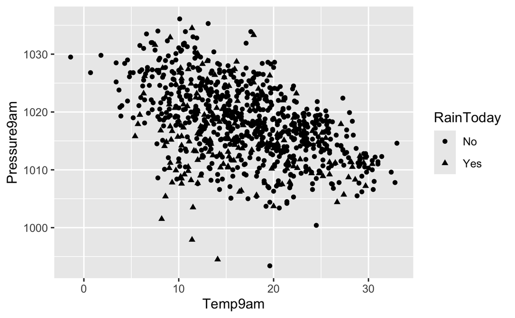

```r
grafico2_b <- grafico2_a + aes(shape = RainToday)
grafico2_b
```

**c)** Modifica el gráfico anterior para incluir información categórica proporcionada por la variable RainToday con el color del punto. ¿Con qué representación (color o forma) se observa mejor la información que introduce la variable RainToday?

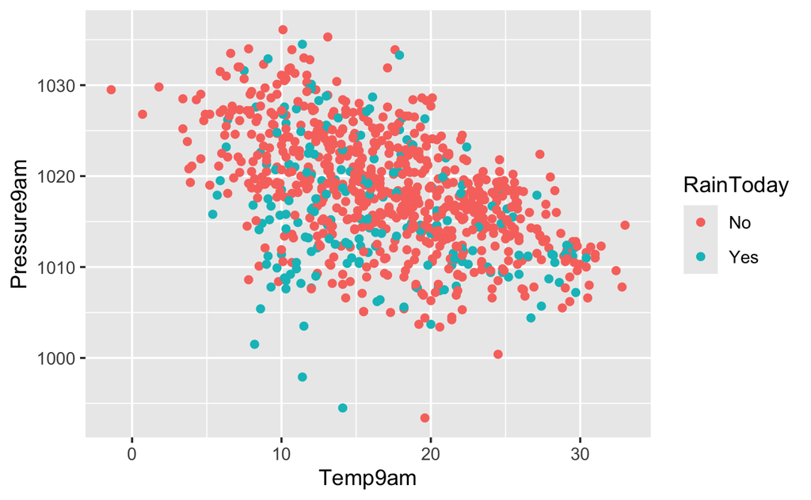

```r
grafico2_c <- grafico2_a + aes(color = RainToday)
grafico2_c
```

Se observa mejor distinguir los puntos por colores más que por forma. Al graficar todo del mismo color, las formas pueden superponerse y no distinguir los triángulos de los círculos.

**d)** Añade títulos explicativos al gráfico anterior (debe aparece un título, subtítulo, leyendas e información de las variables representadas en los ejes).

```r
grafico2_d <- grafico2_c+ labs(title = "Relación entre Temperatura y Presión a las 9 am",
    subtitle = "Distinción entre precipitación hoy.",
    x = "Temperatura @ 9am / (au)",
    y = "Presión @ 9:00 / (au)",
    color = "Precipitación hoy"
  )
```

**e)**Almacena en formato pdf el gráfico resultante en un fichero denominado Ejercicio2.pdf.

```r
ggsave('./results/Ejercicio2.pdf', grafico2_d)
```

# 3 Ejercicio 3

**a)** Carga el fichero iris_tidy.Rdata utilizando lo aprendido en la práctica 1.

```r
load('data/iris_tidy.Rdata')
```

**b)**Utiliza la función str() para ver qué variables contiene el dataset.

```r
str(iris.tidy)
```

```
'data.frame':   600 obs. of  4 variables:
 $ Species: Factor w/ 3 levels "setosa","versicolor",..: 1 1 1 1 1 1 1 1 1 1 ...
 $ Part   : Factor w/ 2 levels "Petal","Sepal": 2 2 2 2 2 2 2 2 2 2 ...
 $ Measure: chr  "Length" "Length" "Length" "Length" ...
 $ Value  : num  5.1 4.9 4.7 4.6 5 5.4 4.6 5 4.4 4.9 ...
```

**c)**Crea un objeto ggplot denominado iris.grafico1 en el que esté definido el conjunto de datos iris.tidy alojado en el fichero iris.tidy.RData y un aesthetics en el que en el eje $x$ esté definida la variable Species y en el eje $y$ esté definida la variable Value.

```r
iris.grafico1 <- ggplot(iris.tidy, aes(x = Species, y = Value))
```

**d)** Añade una capa que defina el objeto geométrico necesario para construir un gráfico de dispersión de las variables Species y Value.

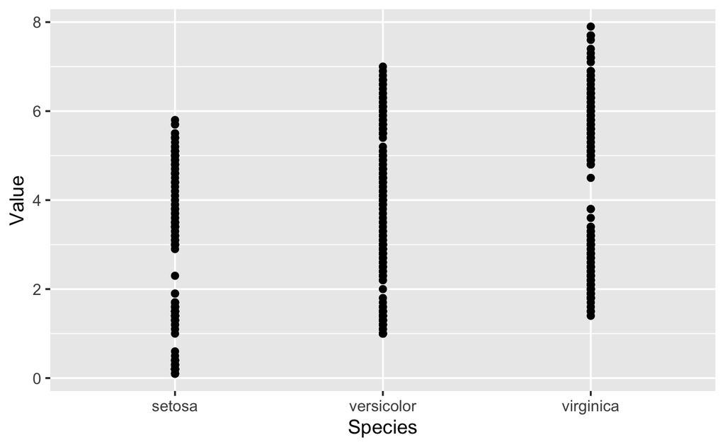

```r
iris.grafico1+geom_point()
```

**e)** Modifica el aesthetics de iris.grafico1 para visualizar la variable categórica Part y almacénalo en iris.grafico2. A partir del objeto iris.grafico2, representa un gráfico de dispersión en el que se muestren los puntos dados por las variables Species y Value, y el color del punto se corresponda con el valor de la variable Part.

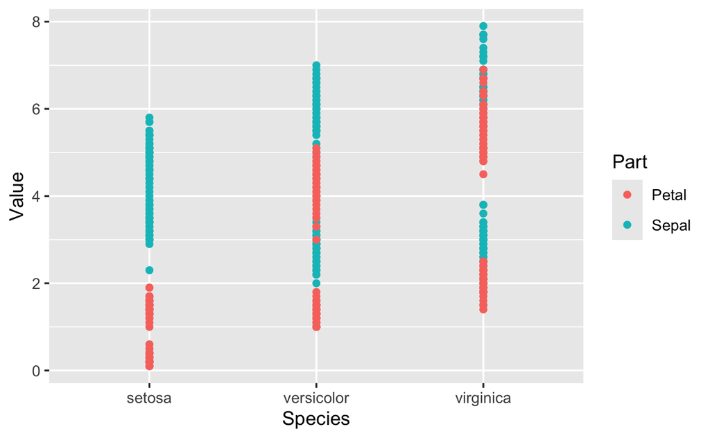

```r
iris.grafico2 <- iris.grafico1+geom_point()+aes(color=Part)
iris.grafico2
```

**f)** Incluye información de la variable Measure haciendo dos gráficos de dispersión (dispuestos en filas) con facet_grid(), como en el apartado de introducción, para los dos valores que toma la variable Measure. Prueba a cambiar la disposición de los gráficos para que sea en columnas ¿Qué disposición, en filas o en columnas, permite comparar mejor los valores de las dos variables?

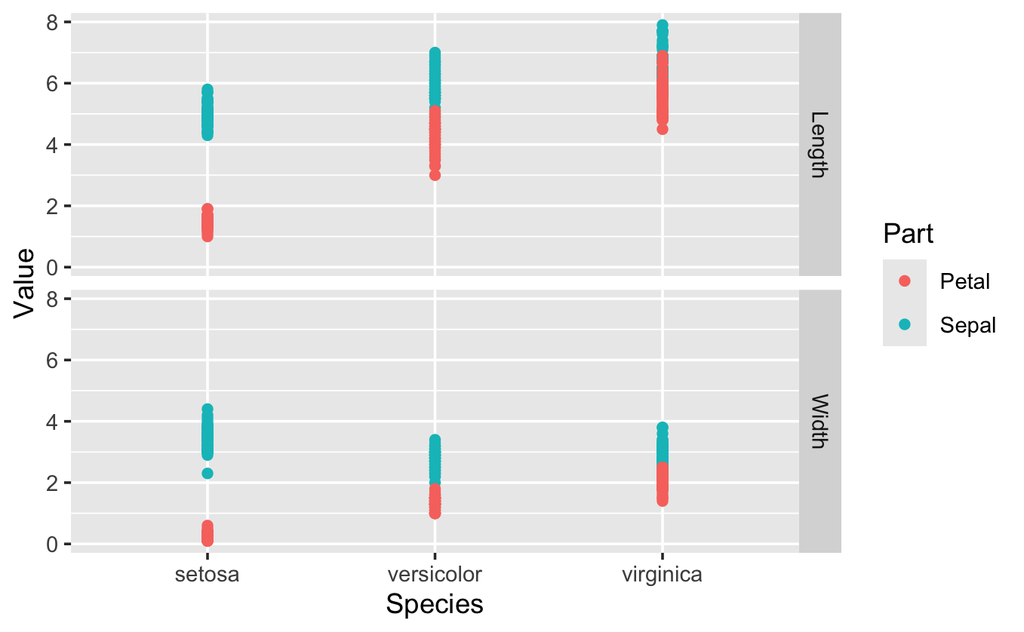

```r
iris.grafico2 + facet_grid(rows = vars(Measure))
```

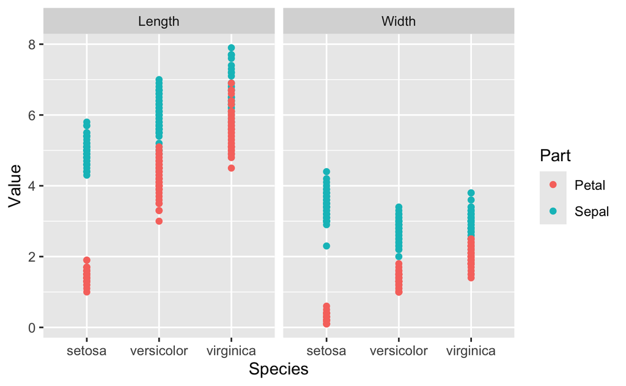

```r
iris.grafico2 + facet_grid(cols = vars(Measure))
```

La mejor disposición es aquella que alinea la variable Value, es decir, en la que obtenemos 1 fila y 2 gráficas. Pese a que la configuración análoga puede ser útil puesto que nos alinea en una columna el tipo de especies, no podemos comparar directamente la variable del eje y que es realmente nuestro objetivo.

**g)**Cambia ahora la capa geom_point() del gráfico anterior por la capa geom_jitter(). ¿Qué diferencia observas?

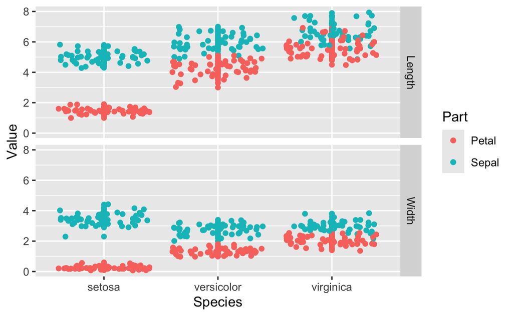

```r
iris.grafico2 + geom_jitter()+ facet_grid(rows = vars(Measure))
```

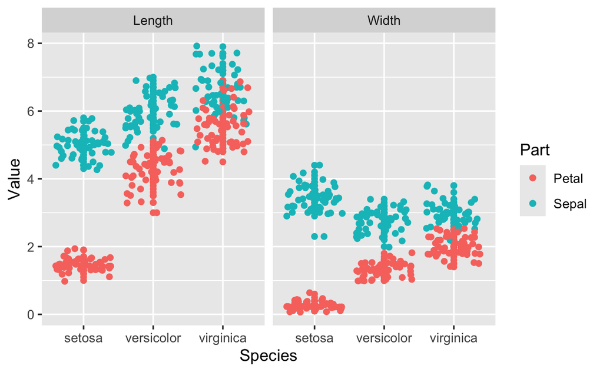

```r
iris.grafico2 + geom_jitter()+ facet_grid(cols = vars(Measure))
```

La diferencia principal es que ahora los datos en vez de estar perfectamente alineados sobre cada una de la categoría de especies se ha añadido un ruido o una pequeña variación en la posición de nuestros datos. Esto es de gran utilidad en nuestro caso porque encontrábamos todos los datos apilados sobre el eje $x$ y, realmente, no se podía apreciar la cantidad de datos que repetían valor.

**h)**Almacena en formato pdf el gráfico resultante en un fichero denominado Ejercicio3.pdf.

```r
ggsave('./results/Ejercicio3.pdf')
```

# 4 Ejercicio 4

**a)**Carga el fichero Ejercicio4_Data.Rdata. Examina las variables que tiene dicho dataset.

```r
load('data/Ejercicio4_Data.Rdata')
head(DatosEjer4)
```

|  | Fecha | Fabricante | Ventas |
| --- | --- | --- | --- |
| 1 | 2002-01-01 | Microsoft | 75.00000 |
| 2 | 2002-02-01 | Microsoft | 67.07002 |
| 3 | 2002-03-01 | Microsoft | 75.49991 |
| 4 | 2002-04-01 | Microsoft | 77.37122 |
| 5 | 2002-05-01 | Microsoft | 68.11144 |
| 6 | 2002-06-01 | Microsoft | 65.64997 |

**b)**Representa un gráfico de puntos, en el que se muestre la fecha en el eje $x$ y las ventas en el eje $y$. Queremos que los datos de cada fabricante sean de un color distinto. ¿Es este gráfico válido para evaluar la evolución de las ventas de cada fabricante?

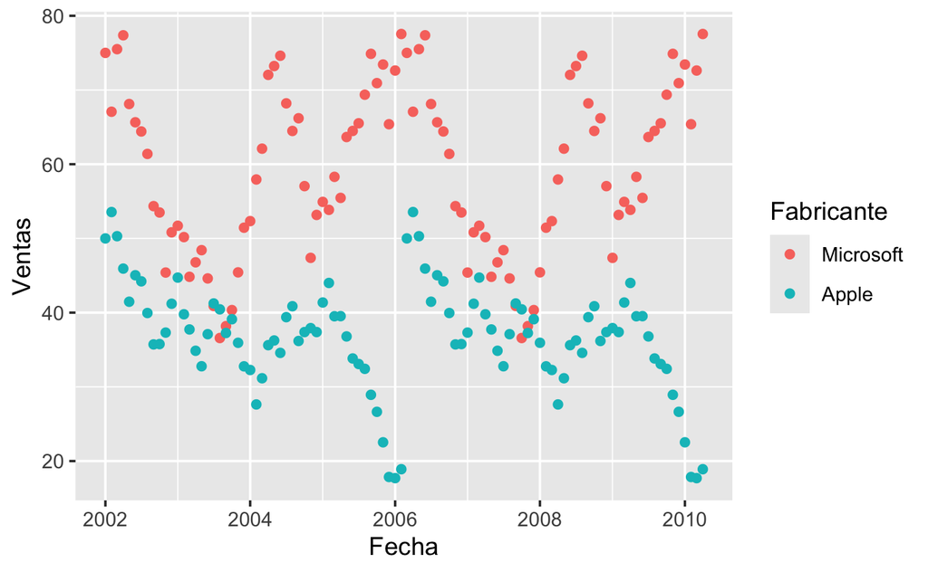

```r
grafico4_b <- ggplot(DatosEjer4, aes(x = Fecha, y = Ventas, color = Fabricante)) + geom_point()

grafico4_b
```

No, no es adecuado porque sin lineas que unan los puntos es complicado saber qué tendencias sigue o qué venta va después de cual.

**c)**Representa un gráfico como el anterior en el que se muestre la línea que une los puntos que antes has representado.

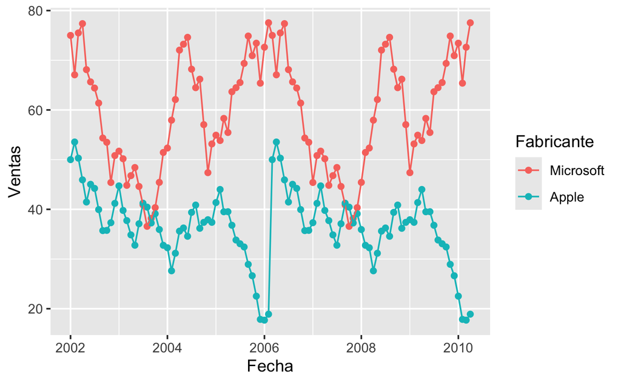

```r
grafico4_c <- grafico4_b+ geom_line()
grafico4_c
```

**d)**Modifica el gráfico anterior para que la tendencia de cada fabricante este trazada con un tipo de línea diferente.

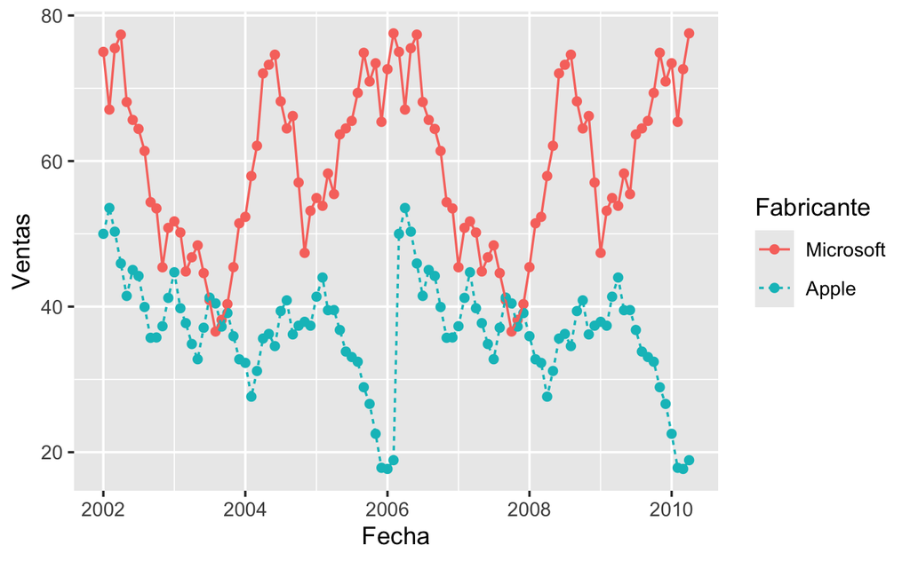

```r
grafico4_d <- grafico4_c+ aes(linetype = Fabricante)
grafico4_d
```

**e)**Añade el siguiente título al gráfico “Ventas mensuales de diferentes compañías tecnológicas”.

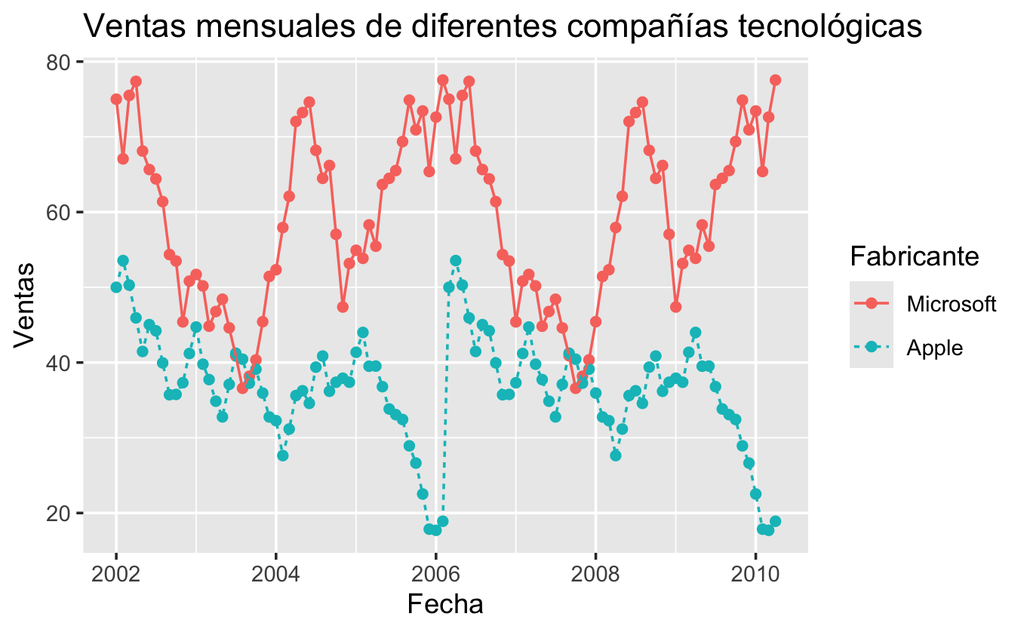

```r
grafico4_e <- grafico4_d+ ggtitle('Ventas mensuales de diferentes compañías tecnológicas')
grafico4_e
```

**f)**Almacena en formato pdf el gráfico resultante en un fichero denominado Ejercicio4.pdf.

```r
ggsave("results/Ejercicio4.pdf")
```

# 5 Ejercicio 5

**a)**Carga el fichero Experimento.Rdata. Examina las variables que tiene dicho dataset.

```r
load('data/Experimento.Rdata')
head(Experimento)
```

|  | Complemento | Dosis | Altura | Error_Altura |
| --- | --- | --- | --- | --- |
| 1 | OJ | 0.5 | 13.23 | 4.459709 |
| 2 | OJ | 1.0 | 22.70 | 3.910953 |
| 3 | OJ | 2.0 | 26.06 | 2.655058 |
| 4 | VC | 0.5 | 7.98 | 2.746634 |
| 5 | VC | 1.0 | 16.77 | 2.515309 |
| 6 | VC | 2.0 | 26.14 | 4.797731 |

**b)**Representa un gráfico de puntos, en el que se muestre la Dosis en el eje $x$ y la Altura en el eje $y$. Queremos que los datos de cada Complemento se representen en una línea diferente con diferentes trazos. Hazlo incluyendo las opciones de tipo de línea y forma del punto dentro del aes() de la capa ggplot.

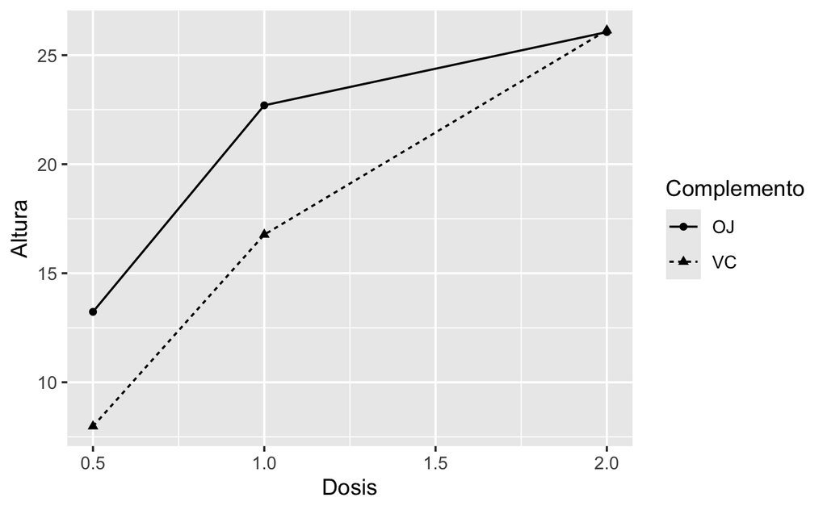

```r
grafico5_b <- ggplot(Experimento, aes(x = Dosis, y = Altura, linetype = Complemento, shape = Complemento))+geom_point()+geom_line()
grafico5_b
```

**c)** Crea otro gráfico añadiendo al gráfico anterior barras de error en cada punto. El error viene dado por la variable Error_Altura.

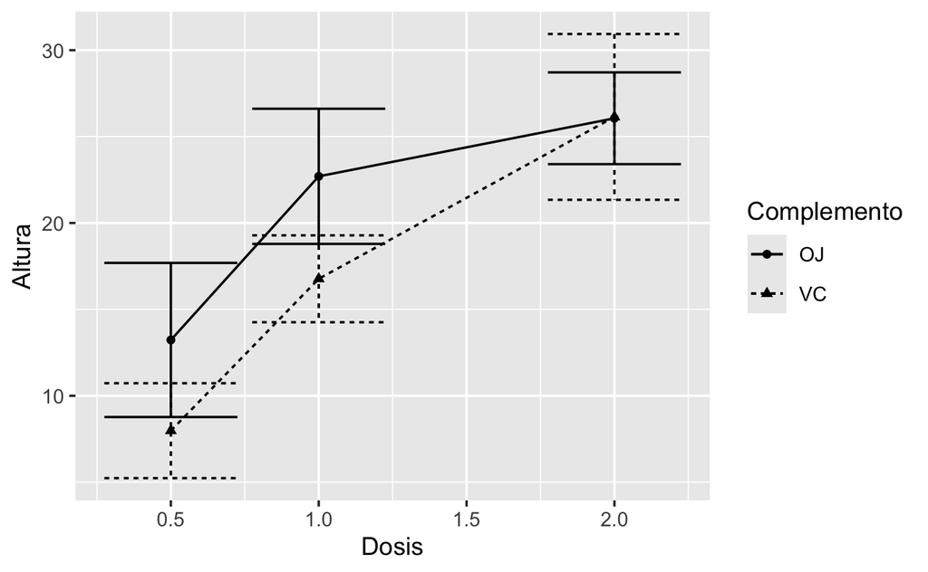

```r
grafico5_c <- grafico5_b + geom_errorbar(aes(ymin = Altura - Error_Altura, ymax = Altura + Error_Altura))

grafico5_c
```

**d)**Crea otro gráfico, como el anterior (idéntico), pero en este caso no puedes incluir el tipo de línea y el tipo de punto en aes() de la capa ggplot. Además queremos que la paleta de colores sea en tonos de rojos (scale_color_brewer).

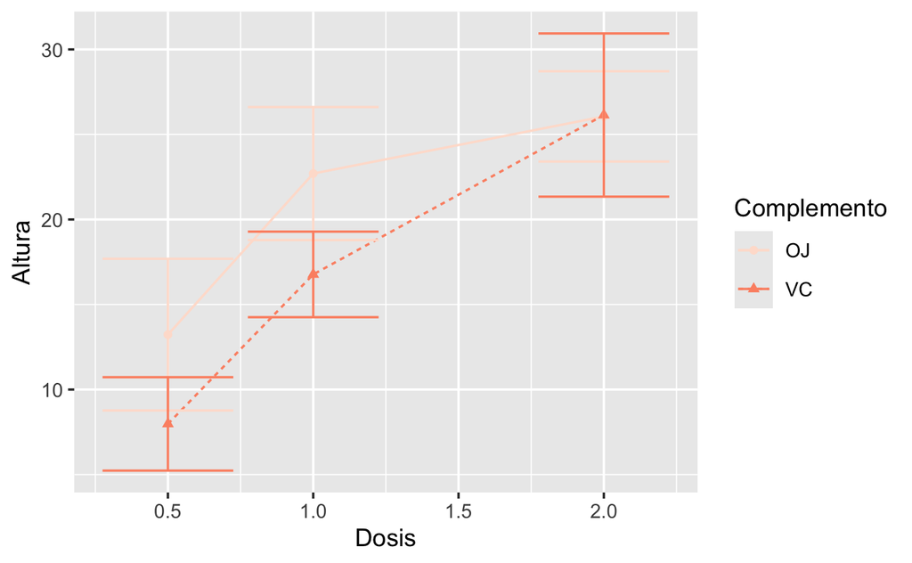

```r
grafico5_d <- ggplot(Experimento, aes(x = Dosis, y = Altura, color = Complemento)) +
  geom_line(aes(linetype = Complemento)) +
  geom_point(aes(shape = Complemento)) +
  geom_errorbar(aes(ymin = Altura - Error_Altura, ymax = Altura + Error_Altura)) +
  scale_color_brewer(palette = "Reds")

grafico5_d
```

**e)**Almacena en formato pdf el gráfico resultante en un fichero denominado Ejercicio5.pdf.

```r
ggsave('results/Ejercicio5.pdf')
```

# 6 Ejercicio 6

**a)** El fichero iceRiver.RData contiene información del caudal de dos ríos islandeses medidos a diarios durante 3 años. Puedes obtener información detallada de las variables usando > ?tseries::ice.river

```r
?tseries::ice.river
```

[output not shown]

**b)** Representa el caudal de ambos ríos a lo largo del período considerado coloreando una serie (flow.vat) en color rojo y la otra en color azul.

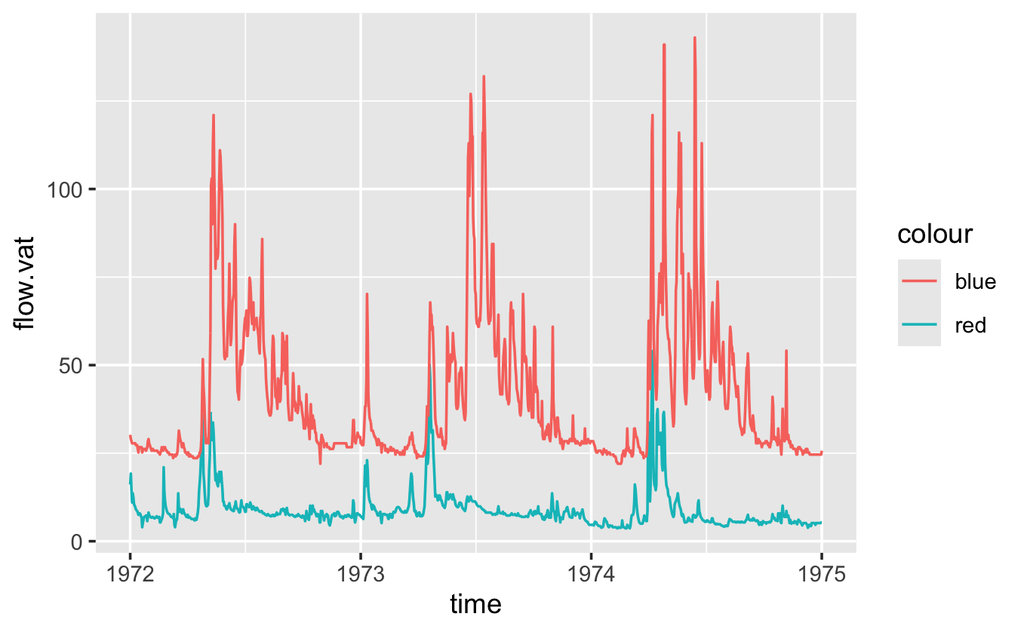

```r
grafico6_b <- ggplot(ice.river.df, aes(x = time)) + geom_line(aes(y = flow.vat, color='red'))+geom_line(aes(y = flow.jok, color='blue'))

grafico6_b
```

**c)** Utiliza la función labs para enriquecer el gráfico.

[figure not shown]

```r
grafico6_c <- grafico6_b + labs(title = "Caudal diario en ríos islandeses", subtitle = "Período 1972 - 1975", x = "Tiempo (Años)", y = "Caudal (au)", color = 'Río')+ scale_color_discrete(labels = c('Vat', "Jok")
  )
grafico6_c
```

**d)** Almacena en formato pdf el gráfico resultante en un fichero denominado Ejercicio6.pdf.

```r
ggsave('./results/Ejercicio6.pdf')
```

# 7 Ejercicio 7

**a)** Carga el fichero weatherAUS_distributions.RData.

```r
str(ds)
```

```
'data.frame':   863 obs. of  24 variables:
 $ Year         : Factor w/ 11 levels "2008","2009",..: 2 7 3 6 5 10 10 7 7 2 ...
 $ Location     : chr  "Richmond" "Albury" "Launceston" "Sale" ...
 $ MinTemp      : num  14.2 13.9 0.4 0.2 10.2 9 8.6 24 12.4 24.4 ...
 $ MaxTemp      : num  29.8 27.7 13.1 15.1 20.7 17.2 23.9 34.2 18 31.9 ...
 $ Rainfall     : num  0.2 1.4 0 0.2 0 1 0 0 2 18.4 ...
 $ Evaporation  : chr  "12.2" NA NA "1.2" ...
 $ Sunshine     : chr  NA NA NA "7.3" ...
 $ WindGustDir  : chr  "NE" "W" "S" "NW" ...
 $ WindGustSpeed: int  28 37 19 17 NA 44 63 41 NA 31 ...
 $ WindDir9am   : chr  NA "ENE" NA "WNW" ...
 $ WindDir3pm   : chr  "E" "NW" "SSE" "NNW" ...
 $ WindSpeed9am : int  0 6 0 9 6 22 13 15 6 11 ...
 $ WindSpeed3pm : int  11 22 4 7 13 30 39 15 35 17 ...
 $ Humidity9am  : int  92 74 98 93 64 71 62 71 84 83 ...
 $ Humidity3pm  : int  36 42 57 57 40 63 22 56 61 68 ...
 $ Pressure9am  : num  1017 1008 1028 1024 1025 ...
 $ Pressure3pm  : num  1014 1007 1026 1021 1020 ...
 $ Cloud9am     : int  NA NA NA 2 5 3 2 6 7 6 ...
 $ Cloud3pm     : int  NA 5 NA 3 7 8 1 3 3 6 ...
 $ Temp9am      : num  18.3 20.9 4.3 3.7 13 12.8 15.4 29.7 15.3 27.9 ...
 $ Temp3pm      : num  29.5 26.4 11.9 14.3 18.7 14.6 23.5 32.1 17.5 30.9 ...
 $ RainToday    : chr  "No" "Yes" "No" "No" ...
 $ RISK_MM      : num  0 0 0.4 0 0 0.2 0 0 1.6 24.2 ...
 $ RainTomorrow : chr  "No" "No" "No" "No" ...
 - attr(*, "spec")=List of 2
  ..$ cols   :List of 24
  .. ..$ Date         :List of 1
  .. .. ..$ format: chr ""
  .. .. ..- attr(*, "class")= chr [1:2] "collector_date" "collector"
  .. ..$ Location     : list()
  .. .. ..- attr(*, "class")= chr [1:2] "collector_character" "collector"
  .. ..$ MinTemp      : list()
  .. .. ..- attr(*, "class")= chr [1:2] "collector_double" "collector"
  .. ..$ MaxTemp      : list()
  .. .. ..- attr(*, "class")= chr [1:2] "collector_double" "collector"
  .. ..$ Rainfall     : list()
  .. .. ..- attr(*, "class")= chr [1:2] "collector_double" "collector"
  .. ..$ Evaporation  : list()
  .. .. ..- attr(*, "class")= chr [1:2] "collector_character" "collector"
```

[output cut: 24 more lines]

```
  .. ..$ Cloud3pm     : list()
  .. .. ..- attr(*, "class")= chr [1:2] "collector_integer" "collector"
  .. ..$ Temp9am      : list()
  .. .. ..- attr(*, "class")= chr [1:2] "collector_double" "collector"
  .. ..$ Temp3pm      : list()
  .. .. ..- attr(*, "class")= chr [1:2] "collector_double" "collector"
  .. ..$ RainToday    : list()
  .. .. ..- attr(*, "class")= chr [1:2] "collector_character" "collector"
  .. ..$ RISK_MM      : list()
  .. .. ..- attr(*, "class")= chr [1:2] "collector_double" "collector"
  .. ..$ RainTomorrow : list()
  .. .. ..- attr(*, "class")= chr [1:2] "collector_character" "collector"
  ..$ default: list()
  .. ..- attr(*, "class")= chr [1:2] "collector_guess" "collector"
  ..- attr(*, "class")= chr "col_spec"
```

**b)** Crea un gráfico en el que estén los boxplots de la variable MinTemp para cada uno de los años presentes en la variable Year del dataset.

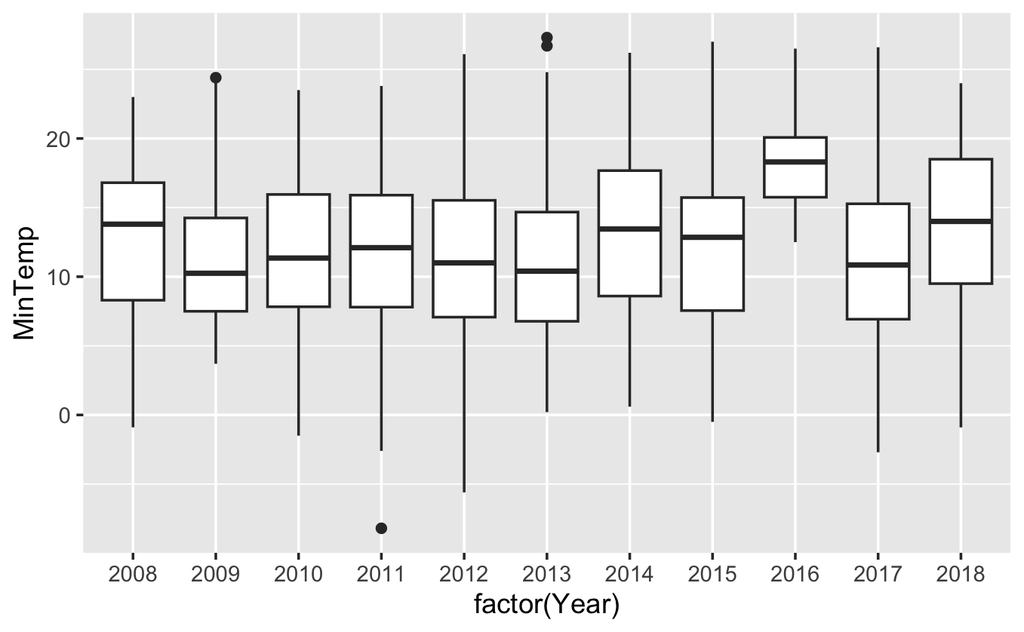

**c)**Crea un gráfico en el que estén los gráficos de violín de la variable MaxTemp para cada uno de los años presentes en la variable Year del dataset. Añade en el mismo gráfico una capa de etiquetas de título (Distribución de temperaturas máximas por año), eje $x$ (Año) y eje $y$ (Temperatura (ºC)). Colorea el interior de los violines según la la variable Year.

[figure not shown]

**d)**En el gráfico anterior elimina la leyenda y coloca los años en el eje $x$ a 45 grados de inclinación. Busca información sobre cómo hacer esto.

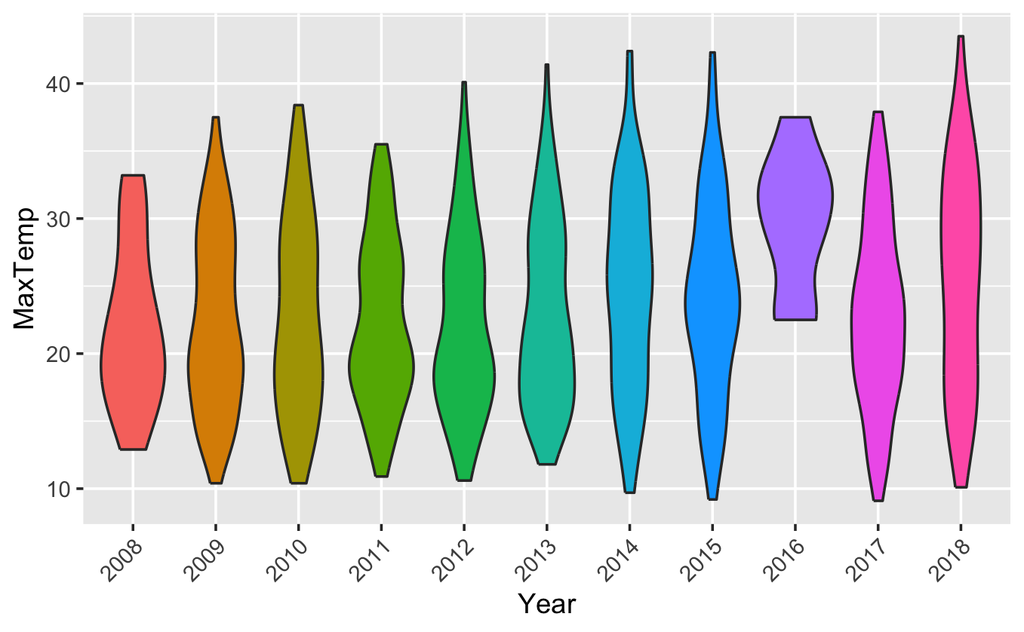

**e)**Almacena en formato pdf el gráfico resultante en un fichero denominado Ejercicio7.pdf.

# 8 Ejercicio 8

**a)** Descarga de la url “http://assets.datacamp.com/blog_assets/chol.txt” el dataset de Datacamp que utilizarás para este ejercicio y cárgalo en un dataframe .

```r
download.file(url= "http://assets.datacamp.com/blog_assets/chol.txt", destfile = "./data/chol.txt")
```

**b)** Representa el histograma de la variable HEIGHT del dataframe cargado del fichero anterior.

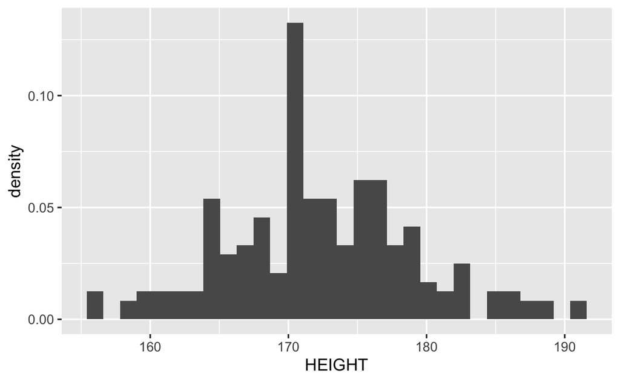

```r
grafico8_b <- ggplot(chol, aes(x = HEIGHT)) +
  geom_histogram(aes(y = after_stat(density)))
grafico8_b
```

**c)**Añade título (“Histograma de la variable Altura”), una etiqueta en el eje $x$ (“Altura (cm)”) y una etiqueta en el eje $y$ (“Frecuencia”).

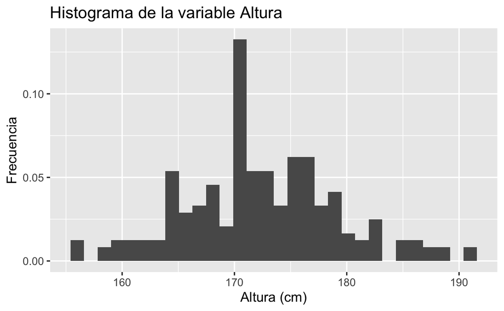

```r
grafico8_c<- grafico8_b+labs(
    title = "Histograma de la variable Altura",
    x = "Altura (cm)",
    y = "Frecuencia"
  )
grafico8_c
```

**d)** Ajusta el rango de representación entre 155 y 195, además fuerza que el histograma tenga 20 bins.(usa parámetro breaks)

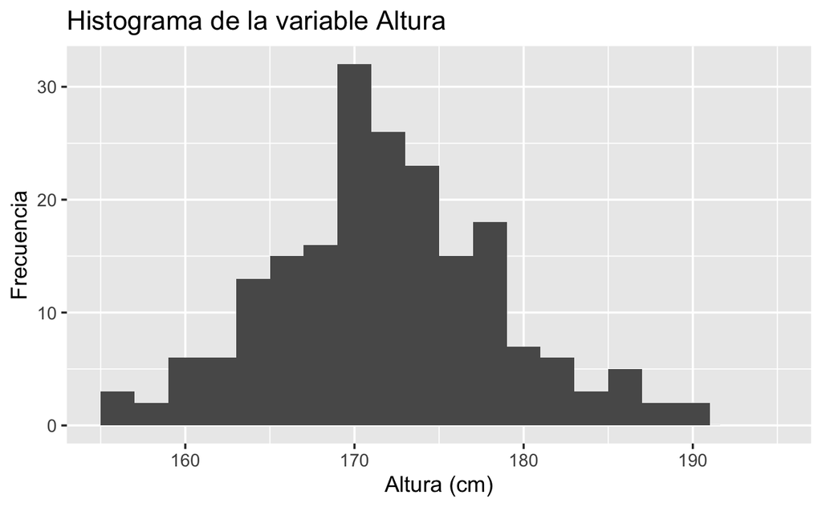

```r
grafico8_d<- grafico8_c + geom_histogram(breaks = seq(155, 195, by = 2))
grafico8_d
```

**e)** Haz que las barras del histograma sean de color azul con una grado de transparencia del 50% y el contorno de color rojo.

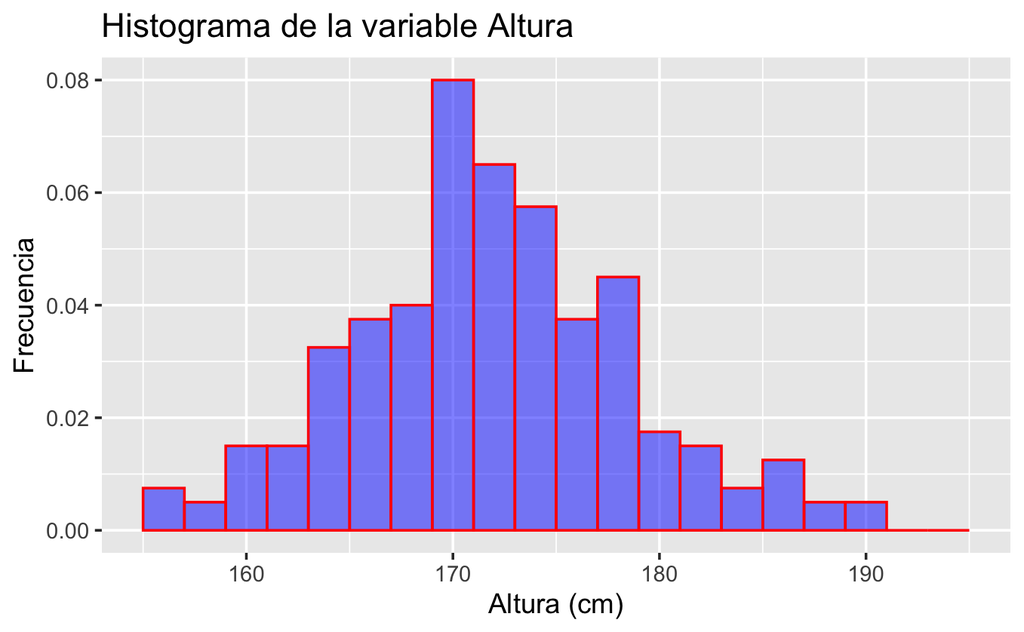

```r
## Me graficaba algo raro y he decdido hacer otro:

grafico8_e <- ggplot(chol, aes(x = HEIGHT)) +
  geom_histogram(aes(y = after_stat(density)),
                 breaks = seq(155, 195, by = 2),
                 fill = "blue",
                 color = "red",
                 alpha = 0.5) +labs(
    title = "Histograma de la variable Altura",
    x = "Altura (cm)",
    y = "Frecuencia")
grafico8_e
```

**f)** Añade la curva de distribución estimada de color verde.

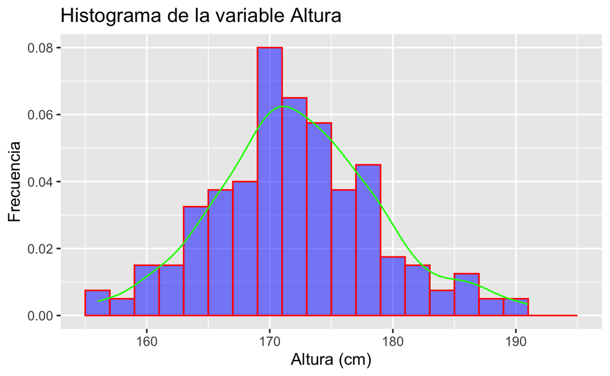

```r
grafico8_f<- grafico8_e +geom_density(color = "green")
grafico8_f
```

**g)**Representa el mismo histograma del apartado anterior para cada valor de la variable MORT, recuerda utilizar la función facet_grid().

```r
facet_grid(. ~ MORT)
```

[output not shown]

[output not shown]

**h)**Almacena en formato pdf el gráfico resultante en un fichero denominado Ejercicio8.pdf.

```r
ggsave("results/Ejercicio8.pdf")
```